# Snail Kite Population Viability Analysis with State-Space models

Stochastic Gompertz State-Space model with Poisson observation error

José Miguel Ponciano, Orlando Acevedo-Charry, Caroline Poli, Meghan Beatty, Lara Elmquist, & Miguel A. Acevedo

26 August 2025

# 1 Packages and functions

First, let’s load the packages in `R` needed to run this code

```r
# R functions and datasets to support "Modern Applied Statistics with S",
  #a book from W.N. Venables and B.D. Ripley
library(MASS);
# R functions for Data Cloning (maximum likelihood estimation using Bayesian MCMC)
library(dclone);
# Create plots for MCMC output
library(mcmcplots)
# Data manipulation and elegant figures
library(tidyverse)
# Palettes inspired by works at the Metropolitan Museum of Art in New York
library(MetBrewer)
```

## 1.1 Functions for initial guesses of parameters and random MVN generator

We will need initial or “naive” guesses of the parameters to fit the state-space model. This could be roughly computing by providing the vector of (log)abundance observations `Yobs` ($\mathbf{N}$) and the vector of observation times `Tvec` with the function `guess.calc()`:

```r
guess.calc <- function(Yobs,Tvec){

  #  For calculations, time starts at zero.
  T.t <-Tvec-Tvec[1];
  #  Number of time series transitions, q.
  q <- length(Yobs)-1;
  #  q+1 gives the length of the time series.
  qp1 <- q+1;
  #  Time intervals
  S.t <- T.t[2:qp1]-T.t[1:q];
  #  Mean of the observations
  Ybar <- mean(Yobs);
  # Variance of the observations
  Yvar <- sum((Yobs-Ybar)*(Yobs-Ybar))/q;
  # Initial mu estimate (at stationary distribution)
  mu1 <- Ybar;

  # Kludge an initial value for theta based on mean of Y(t+s) given Y(t).
  th1 <- -mean(log(abs((Yobs[2:qp1]-mu1)/(Yobs[1:q]-mu1)))/S.t);
  # Moment estimate using stationary
  bsq1 <- 2*th1*Yvar/(1+2*th1);
  # Observation error variance, assumed as first guess as betasq=tausq.
  tsq1 <- bsq1;

  # What to do if initial guesses is three 0's (or NAs)? Assume arbitrary values
  three0s <- sum(c(th1,bsq1,tsq1))
  if(three0s==0|is.na(three0s)){
    th1 <- 0.5;
    bsq1 <- 0.09;
    tsq1 <- 0.23;
    }

  out1 <- c(th1,bsq1,tsq1);

  # What to do if initial guesses are too little? Assume arbitrary values
  if(sum(out1<1e-7)>=1){
    out1 <- c(0.5,0.09,0.23)
  }

  out <- c(mu1,out1);
  return(abs(out))
}
```

To take into account possible NAs in the counts, we can wrap these initial guess estimator function `guess.calc()` into another function `guess.calc2.0()`:

```r
guess.calc2.0<- function(TimeAndNs){

  newmat <- TimeAndNs
  isnas <- sum(is.na(TimeAndNs))

  if(isnas >= 1){

    isnaind <- which(is.na(TimeAndNs[,2]), arr.ind=TRUE)
    newmat <- TimeAndNs[-isnaind,]
    newmat[,1] <- newmat[,1] - newmat[1,1]

  }

  init.guess <- guess.calc(Yobs = log(newmat[,2]), Tvec=newmat[,1])

  mu1  <- init.guess[1]
  th1  <- init.guess[2]
  bsq1 <- init.guess[3]
  sigsq1<- ((1-exp(-2*th1))*bsq1)/(2*th1)

  out <- c(mu=mu1, theta=th1, sigmasq = sigsq1)
  return(out)
}
```

We also need a Multivariate Normal random generator function `randmvn()`, which needs:

1. The number of random samples of a MVN vector: `n`
2. The mean vector of the MVN distribution to sample from: `mu.vec`
3. The variance-covariance matrix of the MVN distribution to sample from: `cov.mat`

```r
randmvn <- function(n, mu.vec, cov.mat){

  # Save the length of the mean vector of the multivariate normal distribution to sample
  p         <- length(mu.vec);
  # The Cholesky decomposition
    #(factorization of a real symmetric positive-definite sqr matrix)
  Tau       <- chol(cov.mat, pivot=TRUE);
  # generate normal deviates outside loop
  Zmat      <- matrix(rnorm(n=p*n,mean=0,sd=1),nrow=p,ncol=n);

  # empty matrix
  out       <- matrix(0,nrow=p,ncol=n);
  # iterate
  for(i in 1:n){
    Z       <- Zmat[,i];
    out[,i] <- t(Tau)%*%Z + mu.vec
  }

  return(out)
}
```

# 2 Water effect on population dynamic and Pr. Falling Under Conservation Threshold

## 2.1 Water data

We have four datasets: \ 1) `wetlands and demes.csv` \ 2) `survey_dates_1997_2025.csv` \ 3) `daily stage in each wetland.csv` \ 4) `snailkite counts by wetland 1997_2025.csv` \

### 2.1.1 Relationship of wetland names and regions

The first serve as a relationship of the names of each wetland and the regions

```r
# relationship of wetlands and regions ####
wetland_region <- read.csv("Code/wetlands and demes.csv") |>
  # adjust name "regions"
  rename(region = deme) |>
  # unify names (spaces and dash as points)
  mutate(wetland = gsub("[- ]", ".", wetland)) |>
  # remove the name of "CATCHMENT" which is "Grassy.Waters.Preserve"
    # and "Fellsmere" which is "SJM"
  filter(!wetland %in% c("CATCHMENT","Fellsmere"))

# count of number of wetlands per region
table(wetland_region$region)
```

```
##
##  EAST  EVER   KRV  OKEE OTHER    PP   SJM
##     5    13    18     3     1     1     3
```

### 2.1.2 Ranges of dates for surveys

```r
# surveys dates to link water level data ####
survey_date <- read.csv("Code/survey_dates_1997_2025.csv") |>
  mutate(start = ymd(start),
         end = ymd(end),
         start.w = floor_date(start-6,"week"),
         end.w = floor_date(start, "week"))
```

### 2.1.3 Daily water level for each wetland

Then, we have the water level for each day in each wetland.

```r
# daily water level ####
daily_wetland_water <- read.csv("Code/daily stage in each wetland.csv") |>
  mutate(date = dmy(Daily.Date)) |>
  pivot_longer(cols = !c("date", "Daily.Date"),
               names_to = "wetland",
               values_to = "daily_water") |>
  mutate(wetland = ifelse(wetland == "Fellsmere", "SJM", wetland))

nrow(daily_wetland_water)
```

```
## [1] 322800
```

We can add the region. Some wetlands were not included, but we can assign them easily

```r
daily_wetland_water |>
  left_join(wetland_region) |>
  filter(is.na(region)) |>
  group_by(wetland) |>
  count()
```

| wetland | n |
| --- | --- |
| Kissimmee.Restoration.Area.N | 10760 |
| Kissimmee.Restoration.Area.S | 10760 |
| STA1W | 10760 |
| Three.Forks.Marsh | 10760 |

```r
daily_wetland_water <- daily_wetland_water |>
  left_join(wetland_region) |>
  mutate(region = ifelse(wetland == "Kissimmee.Restoration.Area.N", "KRV",
                  ifelse(wetland == "Kissimmee.Restoration.Area.S", "KRV",
                  ifelse(wetland == "STA1W", "EVER",
                  ifelse(wetland == "Three.Forks.Marsh", "SJM",
                  region)))),
         region.wetland = paste0(region, "_", wetland)) |>
  group_by(region.wetland) |>
  mutate(mean_stage = mean(daily_water, na.rm = TRUE)) |>
  ungroup() |>
  mutate(center_water = daily_water - mean_stage) |>
  as.data.frame()
table(daily_wetland_water$region)
```

```
##
##   EAST   EVER    KRV   OKEE     PP    SJM
##  21520 107600 118360  21520  10760  43040
```

```r
table(daily_wetland_water$region.wetland)
```

```
##
##      EAST_Grassy.Waters.Preserve          EAST_Loxahatchee.Slough
##                            10760                            10760
##              EVER_Big.Cypress.NP               EVER_Everglades.NP
##                            10760                            10760
##             EVER_Loxahatchee.NWR             EVER_Rotenberger.WMA
##                            10760                            10760
##                       EVER_STA1E                       EVER_STA1W
##                            10760                            10760
##                        EVER_STA5                      EVER_WCA.2B
##                            10760                            10760
##                      EVER_WCA.3A                      EVER_WCA.3B
##                            10760                            10760
##       KRV_East.Lake.Tohopekaliga KRV_Kissimmee.Restoration.Area.C
##                            10760                            10760
## KRV_Kissimmee.Restoration.Area.N KRV_Kissimmee.Restoration.Area.S
##                            10760                            10760
##              KRV_Lake.Hatchineha               KRV_Lake.Istokpoga
##                            10760                            10760
##                 KRV_Lake.Jackson               KRV_Lake.Kissimmee
##                            10760                            10760
##                  KRV_Lake.Marian                  KRV_Lake.Parker
##                            10760                            10760
##            KRV_Lake.Tohopekaliga OKEE_Lake.Hicpochee.Impoundments
##                            10760                            10760
##             OKEE_Lake.Okeechobee                PP_Paynes.Prairie
##                            10760                            10760
##             SJM_Kenansville.Lake                          SJM_SJM
##                            10760                            21520
##            SJM_Three.Forks.Marsh
##                            10760
```

```r
summary(daily_wetland_water)
```

```
##   Daily.Date             date              wetland           daily_water
##  Length:322800      Min.   :1996-01-01   Length:322800      Min.   :-48.70
##  Class :character   1st Qu.:2003-05-13   Class :character   1st Qu.: 11.71
##  Mode  :character   Median :2010-09-23   Mode  :character   Median : 18.68
##                     Mean   :2010-09-23                      Mean   : 27.35
##                     3rd Qu.:2018-02-03                      3rd Qu.: 49.51
##                     Max.   :2025-06-16                      Max.   :378.25
##                                                             NA's   :79946
##     region          region.wetland       mean_stage       center_water
##  Length:322800      Length:322800      Min.   :  2.865   Min.   :-59.50
##  Class :character   Class :character   1st Qu.: 12.766   1st Qu.: -0.57
##  Mode  :character   Mode  :character   Median : 19.945   Median :  0.09
##                                        Mean   : 29.551   Mean   :  0.00
##                                        3rd Qu.: 50.521   3rd Qu.:  0.70
##                                        Max.   :130.384   Max.   :367.45
##                                                          NA's   :79946
```

We can filter the dates for the week before each survey

```r
# Filter water level at the weekly scale for the dates of surveys
www_filt <- pmap(survey_date, function(start.w, end.w, ...) {
  daily_wetland_water |>
    filter(date >= start.w & date <= end.w)
})

www_filt_df <- bind_rows(www_filt, .id = "survey_id")
www_filt_df$X <- as.integer(www_filt_df$survey_id)
www_filt_df <- www_filt_df |>
  arrange(wetland, date)
head(www_filt_df)
```

|  | survey_id | Daily.Date | date | wetland | daily_water | region | region.wetland | mean_stage | center_water | X |
| --- | --- | --- | --- | --- | --- | --- | --- | --- | --- | --- |
| 1 | 1 | 23-Feb-97 | 1997-02-23 | Big.Cypress.NP | 2.42 | EVER | EVER_Big.Cypress.NP | 2.865472 | -0.4454721 | 1 |
| 2 | 2 | 16-Mar-97 | 1997-03-16 | Big.Cypress.NP | 2.34 | EVER | EVER_Big.Cypress.NP | 2.865472 | -0.5254721 | 2 |
| 3 | 2 | 17-Mar-97 | 1997-03-17 | Big.Cypress.NP | 2.32 | EVER | EVER_Big.Cypress.NP | 2.865472 | -0.5454721 | 2 |
| 4 | 2 | 18-Mar-97 | 1997-03-18 | Big.Cypress.NP | 2.30 | EVER | EVER_Big.Cypress.NP | 2.865472 | -0.5654721 | 2 |
| 5 | 2 | 19-Mar-97 | 1997-03-19 | Big.Cypress.NP | 2.28 | EVER | EVER_Big.Cypress.NP | 2.865472 | -0.5854721 | 2 |
| 6 | 2 | 20-Mar-97 | 1997-03-20 | Big.Cypress.NP | 2.26 | EVER | EVER_Big.Cypress.NP | 2.865472 | -0.6054721 | 2 |

There are NAs in the `daily_water` value for the different wetlands. We can assume that the data missing is at random and conduct an imputation using JAGS ([Kery & Royle, 2016](https://www-mbr--pwrc-usgs-gov.translate.goog/pubanalysis/keryroylebook/?_x_tr_sl=en&_x_tr_tl=es&_x_tr_hl=es&_x_tr_pto=tc)). In other words, we can model the relative water level as latent variable, using as predictors the region, wetland, and date. We can include an autoregressive effect (AR1), because each day’s relative water level depends on the previous day’s value when the previous observation belongs to the same wetland.

$$\text{W}_{d} \sim \text{Normal}(\mu_{d},\sigma^{2}) \\
\mu_{d} = \beta_{1} * \text{Date}_{d} + \beta_{2}[\text{Region}_d] + \beta_{3}[\text{Wetland}_{d}] + \phi\times(W_{d-1}-\mu_{d-1})$$
This model adds random intercepts for regions $\beta_{2}[Region_d]\sim\text{Normal}(0,\tau_{\text{region}}^{-1})$, and wetland-specific deviation centered on their region’s effect $\beta_{3}[ Wetland_{d}]\sim\text{Normal}(\beta_2[\text{region}(w)],\tau_{wetland}^{-1})$, where $\text{region}(w)$ maps each wetland $w$ to its parent region. Finally, the AR1 effect $\phi \sim \text{Uniform}(-1,1)$ is added if the previous observation belongs to the same wetland as the current observation. This represents the deviation of the previous observation $W_{d-1}$ from its expected mean $\mu_{d-1}$ to correct the prediction of the current expected value $\mu_{d}$ (error correction model).

```r
Impute.model.w <- function(){
  # Likelihood
  for (d in 2:D) {
    is_same_wetland[d] <- equals(wetland[d], wetland[d - 1])
    mu_w_prev[d] <- beta1_w * date[d-1] + beta2_w[region[d-1]] + beta3_w[wetland[d-1]]
    mu_w[d] <- beta1_w * date[d] + beta2_w[region[d]] + beta3_w[wetland[d]] +
               phi * is_same_wetland[d] * (water[d-1] - mu_w_prev[d])

    water[d] ~ dnorm(mu_w[d], tau_w)
  }

  # Prior for first observation
  water[1] ~ dnorm(mu_w[1], tau_w)
  mu_w[1] <- beta1_w * date[1] + beta2_w[region[1]] + beta3_w[wetland[1]]

  # Priors
  tau_w ~ dgamma(0.01, 0.01)
  beta1_w ~ dnorm(0, 0.01)
  phi ~ dunif(-1, 1)

  for (r in 1:n_regions) {
    beta2_w[r] ~ dnorm(0, tau_region_w)
  }
  tau_region_w ~ dgamma(0.01, 0.01)

  for (w in 1:n_wetlands) {
    beta3_w[w] ~ dnorm(beta2_w[region_for_wetland[w]], tau_wetland_w)
  }
  tau_wetland_w ~ dgamma(0.01, 0.01)
}
```

We need to adjust the data for this model.

```r
data_jags_w <- www_filt_df |>
  dplyr::select(date, region, wetland, center_water) |>
  mutate(
    # generate numeric index for categorical variables
    region = as.numeric(as.factor(region)),
    wetland = as.numeric(as.factor(wetland))
    )

n_wetlands = length(unique(data_jags_w$wetland))

region_for_wetland <- rep(NA, n_wetlands)
for (w in 1:n_wetlands) {
  region_for_wetland[w] <- unique(data_jags_w$region[data_jags_w$wetland == w])
}

dat_w <- list(
 D = nrow(data_jags_w),
 water = ifelse(is.na(data_jags_w$center_water), NA, data_jags_w$center_water),
 date = as.numeric(data_jags_w$date),
 region = data_jags_w$region,
 wetland = data_jags_w$wetland,
 n_regions = length(unique(data_jags_w$region)),
 n_wetlands = length(unique(data_jags_w$wetland)),
 region_for_wetland = region_for_wetland
)
```

Fit the model

```r
Impute.w.fit <- jags.fit(data = dat_w,
                       params = c("water","phi"),
                       model = Impute.model.w)
saveRDS(Impute.w.fit, "Code/Impute_Relative_Water_fit_AR1_noBeta0.rds")
```

Extract posterior means and add to original data to see the missing values

```r
# Convert to matrix
mcmc_mat <- as.matrix(Impute.w.fit)

# Extract posterior means
water_means <- colMeans(mcmc_mat[, grep("^water\\[", colnames(mcmc_mat))])

# Add new columns with imputed values
www_filt_df$water_imputed <- www_filt_df$center_water
www_filt_df$water_imputed[is.na(www_filt_df$center_water)] <- water_means[is.na(www_filt_df$center_water)]

saveRDS(www_filt_df, "data/www_center_filtered_df_impute_AR1_noBeta0.RDS")
```

And we can explore how this imputation performed.

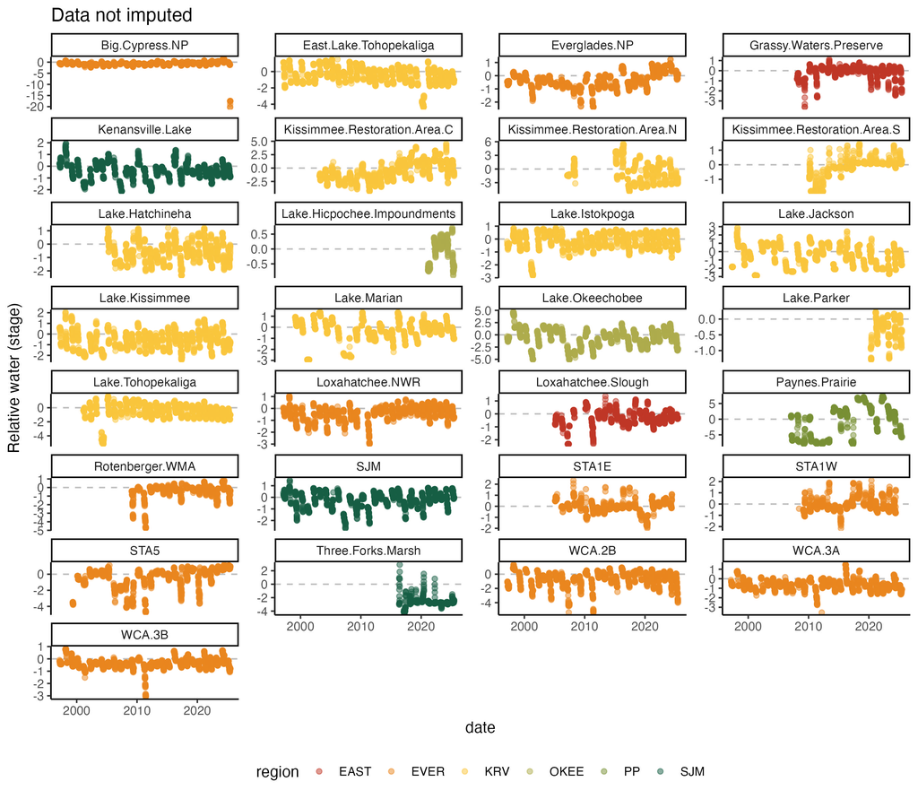

Pre

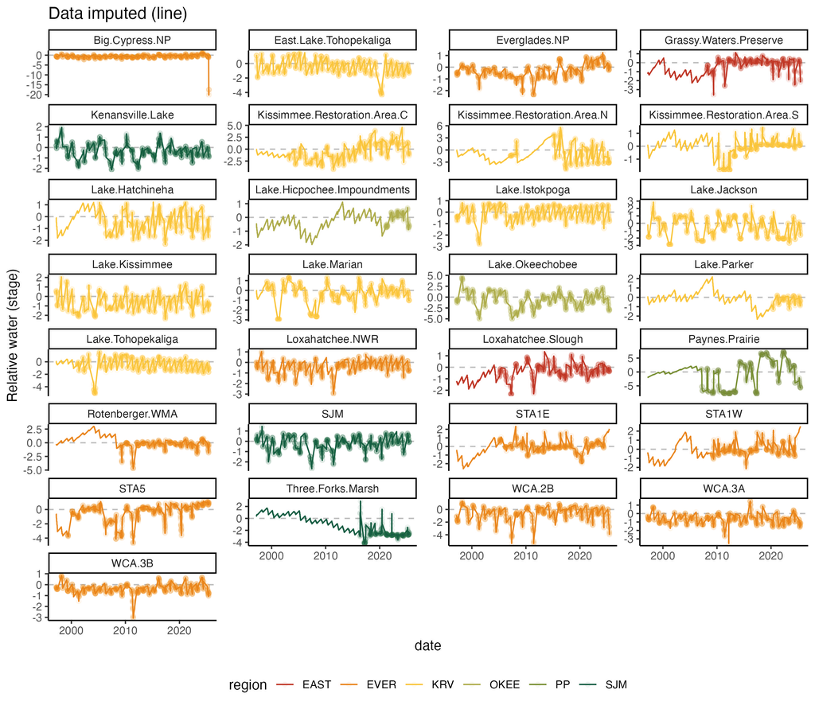

Post

```r
www_filt_df <- readRDS("data/www_center_filtered_df_impute_AR1_noBeta0.RDS") |>
  filter(wetland != "Fellsmere")

www_filt_df_pre <- www_filt_df |>
  mutate(wet.reg = paste0(region, "_", wetland)) |>
  ggplot(aes(x = date, y = center_water, color = region)) +
  geom_hline(yintercept = 0, linetype = "dashed", color = "gray")+
  facet_wrap(~wetland, scales = "free_y", ncol = 4) +
  geom_point(alpha = 0.5)+
  scale_color_manual(values=met.brewer("Homer2",n = 6)) +
  scale_fill_manual(values=met.brewer("Homer2"),n = 6) +
  labs(title = "Data not imputed",
       y = "Relative water (stage)")+
  theme_classic()+
  theme(legend.position = "bottom")+
  guides(color = guide_legend(nrow = 1),
         fill = guide_legend(nrow = 1))

ggsave(filename = "ww_pre_impute.jpg", www_filt_df_pre, dpi = 300,
       width = 230, height = 200, units = "mm")
www_filt_df_post <- www_filt_df |>
  mutate(wet.reg = paste0(region, "_", wetland)) |>
  ggplot(aes(x = date, y = center_water, color = region)) +
  geom_hline(yintercept = 0, linetype = "dashed", color = "gray")+
  facet_wrap(~wetland, scales = "free_y", ncol = 4) +
  geom_line(aes(y = water_imputed))+
  geom_point(alpha = 0.05)+
  labs(title = "Data imputed (line)",
       y = "Relative water (stage)")+
  scale_color_manual(values=met.brewer("Homer2",n = 6)) +
  scale_fill_manual(values=met.brewer("Homer2"),n = 6) +
  theme_classic()+
  theme(legend.position = "bottom")+
  guides(color = guide_legend(nrow = 1),
         fill = guide_legend(nrow = 1))

ggsave(filename = "ww_post_impute.jpg", www_filt_df_post, dpi = 300,
       width = 230, height = 200, units = "mm")
```

### 2.1.4 Counts per wetlands across 6 surveys per year

This dataset include the counts per survey

```r
# Counts per wetland in 6 regions ####
snki_N_wetland <- read.csv("Code/snailkite counts by wetland 1997_2025.csv")
names(snki_N_wetland)
```

```
##  [1] "X"                            "year"
##  [3] "survey_num"                   "A.1.FEB"
##  [5] "Arbuckle"                     "Big.Cypress.NP"
##  [7] "C.23.Reservoir"               "C.44.Impoundment"
##  [9] "CATCHMENT"                    "East.Lake.Tohopekaliga"
## [11] "Everglades.NP"                "Fellsmere"
## [13] "Grassy.Waters.Preserve"       "Hungryland"
## [15] "Johns.Lake"                   "Kenansville.Lake"
## [17] "Kissimmee.Restoration.Area.C" "Lake.Arbuckle"
## [19] "Lake.Cypress"                 "Lake.Hatchineha"
## [21] "Lake.Hicpochee.Impoundments"  "Lake.Istokpoga"
## [23] "Lake.Jackson"                 "Lake.Kissimmee"
## [25] "Lake.Marian"                  "Lake.Monroe"
## [27] "Lake.Okeechobee"              "Lake.Parker"
## [29] "Lake.Rosalie"                 "Lake.Tohopekaliga"
## [31] "Lake.Weohyakapka"             "Loxahatchee.NWR"
## [33] "Loxahatchee.Slough"           "Mary.A..Mitigation.Bank"
## [35] "Paynes.Prairie"               "Rotenberger.WMA"
## [37] "SJM"                          "STA.Lakeside.Ranch"
## [39] "STA1E"                        "STA2"
## [41] "STA3"                         "STA5"
## [43] "Shingle.Marsh"                "Tiger.Lake"
## [45] "WCA.2A"                       "WCA.2B"
## [47] "WCA.3A"                       "WCA.3B"
## [49] "OTHER"
```

Converting in a long format matches the organization of the water level, which we can add and then extract the mean and standard deviation value for each week before each survey (immediate conditions pre-survey might affect the counts).

```r
# long format with water level per survey
snki_N_wetland_region <- snki_N_wetland |>
  # move wetland columns to a single, having the count reported
  pivot_longer(cols = !c(X, year, survey_num),
               names_to = "wetland",
               values_to = "count") |>
  mutate(wetland = ifelse(wetland == "CATCHMENT", "Grassy.Waters.Preserve",
                          wetland),
         wetland = ifelse(wetland == "Fellsmere", "SJM",
                          wetland),
         wetland = ifelse(wetland == "Arbuckle", "Lake.Arbuckle",
                          wetland)) |>
  # merge with the daily water wetland level
  left_join(www_filt_df |>
              select(X, wetland, water_imputed)) |>
  filter(!is.na(water_imputed) | !is.na(count)) |>
  # merge the region
  left_join(wetland_region) |>
  rename(survey_id = X) |>
  # extract survey mean and CV
  group_by(region, wetland, year, survey_id, survey_num) |>
  summarise(
    count = round(mean(count, na.rm = TRUE),0),
    mu_water = mean(water_imputed, na.rm = TRUE),
    sd_water = sd(water_imputed, na.rm = TRUE)) |>
  arrange(region, wetland, year) |>
  as.data.frame()
```

```
## You can override using the `.groups` argument.
```

We can explore which wetlands has more data

```r
snki_N_wetland_region |>
  mutate(region = ifelse(wetland == "STA.Lakeside.Ranch","OTHER",
                         region)) |>
  # to summarize, `group_by()`
  group_by(region, wetland) |>
  # remove NA surveys
  drop_na(count) |>
  # how many surveys per wetland?
  count() |>
  # sort the information (for Table 1 in the report)
  arrange(region, -n) |>
  filter(region != "OTHER") |>
  as.data.frame()
```

| region | wetland | n |
| --- | --- | --- |
| EAST | Grassy.Waters.Preserve | 126 |
| EAST | Hungryland | 83 |
| EAST | C.44.Impoundment | 13 |
| EAST | C.23.Reservoir | 10 |
| EAST | Loxahatchee.Slough | 7 |
| EVER | WCA.3A | 161 |
| EVER | WCA.2B | 158 |
| EVER | Loxahatchee.NWR | 134 |
| EVER | WCA.2A | 132 |
| EVER | WCA.3B | 127 |

[output cut: 31 more lines]

And we select to work with those wetlands with surveys ≥75% of the data in relation with the maximum per region. For example, OKEE include two wetlands, the maximum number of surveys is for Lake Okeechobee (148), the 75% is 111; thus, the second wetland (Lake Hicpochee Impoundments) with only 15 surveys does not have enough surveys.

```r
snki_N_water <- snki_N_wetland_region |>
  # here we can select the wetlands with more data to represent each region
  filter(wetland %in% c(
    "Grassy.Waters.Preserve", # EAST
    "WCA.3A", # EVER
    "WCA.2B", # EVER
    "Loxahatchee.NWR", # EVER
#    "WCA.2A", # EVER - but does not have hydrology gauge data
    "WCA.3B", # EVER
    "Everglades.NP", # EVER
    "STA1E", # EVER
    "East.Lake.Tohopekaliga", # KRV
    "Lake.Kissimmee", # KRV
    "Lake.Istokpoga", # KRV
    "Lake.Hatchineha", # KRV - below threshold of surveys, but added for managers interest
    "Lake.Tohopekaliga", # KRV - below threshold of surveys, but added for managers interest
    "Lake.Okeechobee", # OKEE
    "Paynes.Prairie", # PP
    "SJM" # SJM
    )) |>
  # unify in a single name
  mutate(region.wetland = paste(region, wetland, sep = "_")) |>
  filter(year != 2025) |>
  arrange(region.wetland,year) |>
  as.data.frame()
```

### 2.1.5 Matrix form of the counts and mean water level the week before starting the survey

Data frame for the counts

```r
snki_counts <- snki_N_water |>
  dplyr::select(year, survey_num, region.wetland, count) |>
  pivot_wider(names_from = region.wetland, values_from = count) |>
  as.data.frame()
```

Data frame for the water level mean (of the week before starting the survey)

```r
snki_water <- snki_N_water |>
  dplyr::select(year, survey_num, region.wetland, mu_water) |>
  pivot_wider(names_from = region.wetland, values_from = mu_water) |>
  as.data.frame()
```

Data frame for the water level standard deviation (of the week before starting the survey)

```r
snki_water_SD <- snki_N_water |>
  dplyr::select(year, survey_num, region.wetland, sd_water) |>
  pivot_wider(names_from = region.wetland, values_from = sd_water) |>
  as.data.frame()
```

And generate the three matrices

```r
names.snkicounts <- names(snki_counts)
wet.names <- c(
  "EAST_Grassy.Waters.Preserve", # EAST
    "EVER_WCA.3A", # EVER
    "EVER_WCA.2B", # EVER
    "EVER_Loxahatchee.NWR", # EVER
#    "WCA.2A", # EVER - but does not have hydrology gauge data
    "EVER_WCA.3B", # EVER
    "EVER_Everglades.NP", # EVER
    "EVER_STA1E", # EVER
    "KRV_East.Lake.Tohopekaliga", # KRV
    "KRV_Lake.Kissimmee", # KRV
    "KRV_Lake.Istokpoga", # KRV
    "KRV_Lake.Hatchineha", # KRV - below threshold of surveys, but added for managers interest
    "KRV_Lake.Tohopekaliga", # KRV - below threshold of surveys, but added for managers interest
    "OKEE_Lake.Okeechobee", # OKEE
    "PP_Paynes.Prairie", # PP
    "SJM_SJM" # SJM
  )
cols.with.counts <- match(wet.names, names.snkicounts)
years <- unique(snki_counts$year)
nyears <- length(years)
year.col <- which(names.snkicounts=="year",arr.in=TRUE)
surv.num <- unique(snki_counts$survey_num)
tt <- years - years[1]

S4mat <- S5mat <- S6mat <- matrix(0, nrow=length(wet.names), ncol=nyears)

Counts.list <- list(S4mat = S4mat, S5mat=S5mat, S6mat=S6mat)
Water.list <- list(W4mat =  S4mat, W5mat=S5mat, W6mat=S6mat)
WaterSD.list <- list(W4matSD =  S4mat, W5matSD=S5mat, W6matSD=S6mat)

for(i in 1:3){
  SN <- surv.num[(i+3)]
  ith.rows   <- which(snki_counts$survey_num==SN, arr.ind=TRUE)

  ith.datmat <- t(snki_counts[ith.rows, cols.with.counts])
  ith.watmat <- t(snki_water[ith.rows, cols.with.counts])
  ith.watSDmat <- t(snki_water_SD[ith.rows, cols.with.counts])
  colnames(ith.datmat) <- colnames(ith.watmat) <- colnames(ith.watSDmat) <- tt

  Counts.list[[i]] <- ith.datmat
  Water.list[[i]] <- ith.watmat
  WaterSD.list[[i]] <- ith.watSDmat
}
```